# Assignment

## Mohammad Ahmadi. Data Science Foundation Assignment. Heart Disease Prediction.

## Exploratory data analysis

#### Loading required libraries

```python
import numpy as np
import pandas as pd
import matplotlib.pyplot as plt
import seaborn as sns

import warnings
warnings.filterwarnings("ignore")
```

#### Loading the data

```python
patient = pd.read_csv("heart.csv")
```

#### 5 top rows

```python
patient.head()
```

|  | Age | Sex | ChestPainType | RestingBP | Cholesterol | FastingBS | RestingECG | MaxHR | ExerciseAngina | Oldpeak | ST_Slope | HeartDisease |
| --- | --- | --- | --- | --- | --- | --- | --- | --- | --- | --- | --- | --- |
| 0 | 40 | M | ATA | 140 | 289 | 0 | Normal | 172 | N | 0.0 | Up | 0 |
| 1 | 49 | F | NAP | 160 | 180 | 0 | Normal | 156 | N | 1.0 | Flat | 1 |
| 2 | 37 | M | ATA | 130 | 283 | 0 | ST | 98 | N | 0.0 | Up | 0 |
| 3 | 48 | F | ASY | 138 | 214 | 0 | Normal | 108 | Y | 1.5 | Flat | 1 |
| 4 | 54 | M | NAP | 150 | 195 | 0 | Normal | 122 | N | 0.0 | Up | 0 |

#### 5 last rows

```python
patient.tail()
```

|  | Age | Sex | ChestPainType | RestingBP | Cholesterol | FastingBS | RestingECG | MaxHR | ExerciseAngina | Oldpeak | ST_Slope | HeartDisease |
| --- | --- | --- | --- | --- | --- | --- | --- | --- | --- | --- | --- | --- |
| 913 | 45 | M | TA | 110 | 264 | 0 | Normal | 132 | N | 1.2 | Flat | 1 |
| 914 | 68 | M | ASY | 144 | 193 | 1 | Normal | 141 | N | 3.4 | Flat | 1 |
| 915 | 57 | M | ASY | 130 | 131 | 0 | Normal | 115 | Y | 1.2 | Flat | 1 |
| 916 | 57 | F | ATA | 130 | 236 | 0 | LVH | 174 | N | 0.0 | Flat | 1 |
| 917 | 38 | M | NAP | 138 | 175 | 0 | Normal | 173 | N | 0.0 | Up | 0 |

#### Shape

```python
# checking the shape of train data
patient.shape
```

[output not shown]

##### Observation

- There are total 918 rows and 12 columns.

#### Detailed information about dataset

```python
patient.info()
```

```
<class 'pandas.core.frame.DataFrame'>
RangeIndex: 918 entries, 0 to 917
Data columns (total 12 columns):
 #   Column          Non-Null Count  Dtype
---  ------          --------------  -----
 0   Age             918 non-null    int64
 1   Sex             918 non-null    object
 2   ChestPainType   918 non-null    object
 3   RestingBP       918 non-null    int64
 4   Cholesterol     918 non-null    int64
 5   FastingBS       918 non-null    int64
 6   RestingECG      918 non-null    object
 7   MaxHR           918 non-null    int64
 8   ExerciseAngina  918 non-null    object
 9   Oldpeak         918 non-null    float64
 10  ST_Slope        918 non-null    object
 11  HeartDisease    918 non-null    int64
dtypes: float64(1), int64(6), object(5)
memory usage: 86.2+ KB
```

##### Observation

- There are total 918 rows and 12 columns that all contain non_null values.
- Also dtypes of columns are float64(1), int64(6), object(5)
- this data set get 86.2 KB of memory space

#### Statistical Analysis

```python
patient.describe()
```

|  | Age | RestingBP | Cholesterol | FastingBS | MaxHR | Oldpeak | HeartDisease |
| --- | --- | --- | --- | --- | --- | --- | --- |
| count | 918.000000 | 918.000000 | 918.000000 | 918.000000 | 918.000000 | 918.000000 | 918.000000 |
| mean | 53.510893 | 132.396514 | 198.799564 | 0.233115 | 136.809368 | 0.887364 | 0.553377 |
| std | 9.432617 | 18.514154 | 109.384145 | 0.423046 | 25.460334 | 1.066570 | 0.497414 |
| min | 28.000000 | 0.000000 | 0.000000 | 0.000000 | 60.000000 | -2.600000 | 0.000000 |
| 25% | 47.000000 | 120.000000 | 173.250000 | 0.000000 | 120.000000 | 0.000000 | 0.000000 |
| 50% | 54.000000 | 130.000000 | 223.000000 | 0.000000 | 138.000000 | 0.600000 | 1.000000 |
| 75% | 60.000000 | 140.000000 | 267.000000 | 0.000000 | 156.000000 | 1.500000 | 1.000000 |
| max | 77.000000 | 200.000000 | 603.000000 | 1.000000 | 202.000000 | 6.200000 | 1.000000 |

##### Observation

- count is the total number of value for each variable that here is 918 for all variables
- we can see other statistical information about each variable including mean, median, minimum, maximum, lower and upper quartile

#### Frequency of unique values

```python
patient.nunique()
```

```
Age                50
Sex                 2
ChestPainType       4
RestingBP          67
Cholesterol       222
FastingBS           2
RestingECG          3
MaxHR             119
ExerciseAngina      2
Oldpeak            53
ST_Slope            3
HeartDisease        2
dtype: int64
```

##### Observation

- the number of unique values for each feature.

#### Distribution of features with histogram

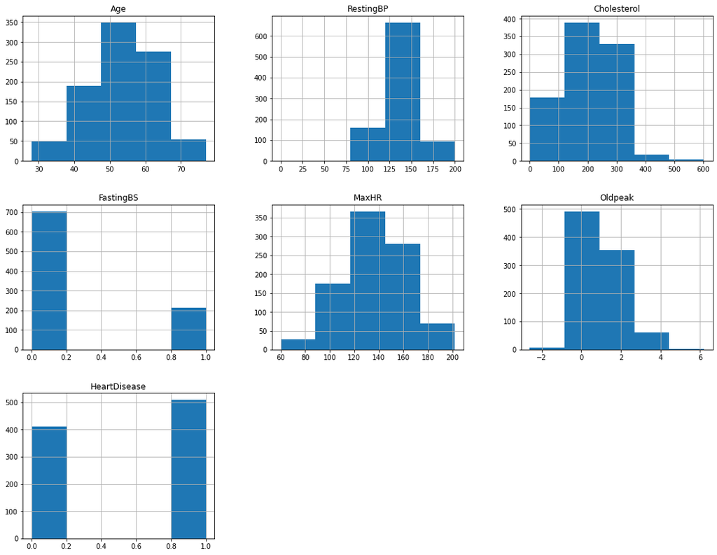

```python
patient.hist(figsize=(18,14),bins=5)
plt.show()
```

##### Observation

- Age, RestingBP and MaxHR are distributed almost normal. Although Oldpeak is right skewed but steel can be considered normal. Regarding cholesterol the distribition is also normal, but the number of ziro values are quite high and should be check with domain knowldge that these ziro values are corect or not.

#### Additional Information by Visualization

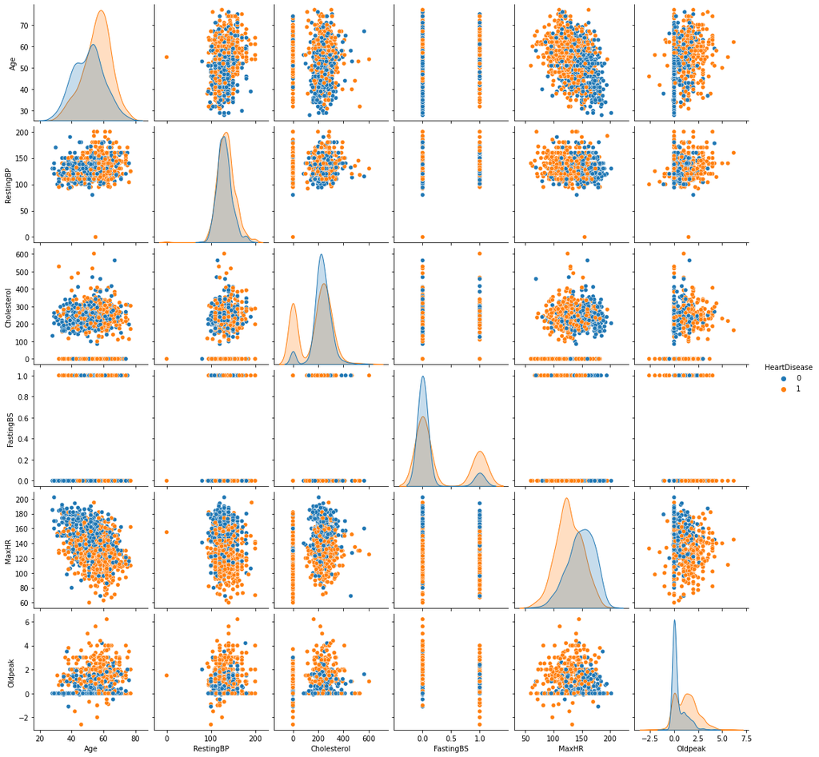

```python
sns.pairplot(data=patient, hue="HeartDisease")
plt.show()
```

##### Observation

- with pairplot we can see the relationship of all pair of numerical features and if enabaling the the hue as abouve plots, we can observe the relation of these future with our target value.

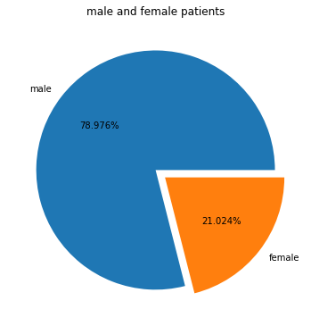

```python
plt.figure(figsize=(6,9))
plt.title("male and female patients")
values = patient["Sex"].value_counts()
plt.pie(values, labels=["male","female"], explode=(0,0.1), autopct="%.3f%%", )
plt.show()
```

##### Observation

- most of the patients are male and this may be important in our furthur steps or using or results of the model

#### Correlations

```python
corr = patient.corr()
corr
```

|  | Age | RestingBP | Cholesterol | FastingBS | MaxHR | Oldpeak | HeartDisease |
| --- | --- | --- | --- | --- | --- | --- | --- |
| Age | 1.000000 | 0.254399 | -0.095282 | 0.198039 | -0.382045 | 0.258612 | 0.282039 |
| RestingBP | 0.254399 | 1.000000 | 0.100893 | 0.070193 | -0.112135 | 0.164803 | 0.107589 |
| Cholesterol | -0.095282 | 0.100893 | 1.000000 | -0.260974 | 0.235792 | 0.050148 | -0.232741 |
| FastingBS | 0.198039 | 0.070193 | -0.260974 | 1.000000 | -0.131438 | 0.052698 | 0.267291 |
| MaxHR | -0.382045 | -0.112135 | 0.235792 | -0.131438 | 1.000000 | -0.160691 | -0.400421 |
| Oldpeak | 0.258612 | 0.164803 | 0.050148 | 0.052698 | -0.160691 | 1.000000 | 0.403951 |
| HeartDisease | 0.282039 | 0.107589 | -0.232741 | 0.267291 | -0.400421 | 0.403951 | 1.000000 |

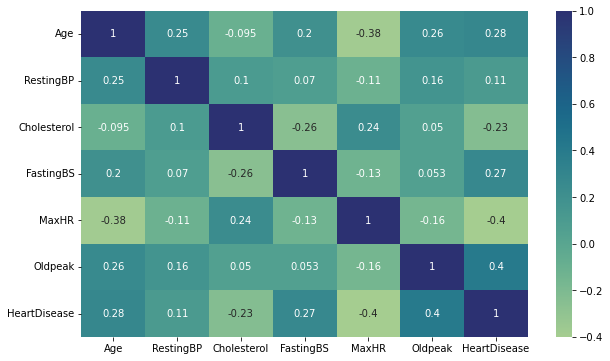

```python
plt.figure(figsize=(10,6))
sns.heatmap(patient.corr(), annot =True, cmap = 'crest')
```

##### Observation

- corelation of +1 arepresents the correlation of each variable with itself, which is always perfect and not informative. Values near +1 and -1 indicate high positive or negative corelation and depending on our situation we can drop one of the variables that are corelated strongly. In our case, as we dont have any corelation more than 0.5 we do not drop any feature.

## Data Cleaning and Feature Engineering

#### Count of null values

```python
Null = patient.isnull().sum()
Null
```

```
Age               0
Sex               0
ChestPainType     0
RestingBP         0
Cholesterol       0
FastingBS         0
RestingECG        0
MaxHR             0
ExerciseAngina    0
Oldpeak           0
ST_Slope          0
HeartDisease      0
dtype: int64
```

##### Observation

- As it is clear we do not have any null values in our dataset

#### Removing duplicates

```python
patient.drop_duplicates(keep="first",inplace=True)
```

```python
patient.shape
```

```
(918, 12)
```

##### Observation

- No change in the shape of our dataset after droping duplicate indicates that there were no duplicates.

#### Imbalance class value

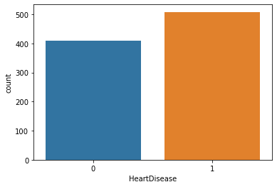

```python
sns.countplot(x = 'HeartDisease', data=patient)
```

##### Observation

- We do not have most of our data in one class. So our target value is not imbalance and we can cotinue to modeling

#### Outliers

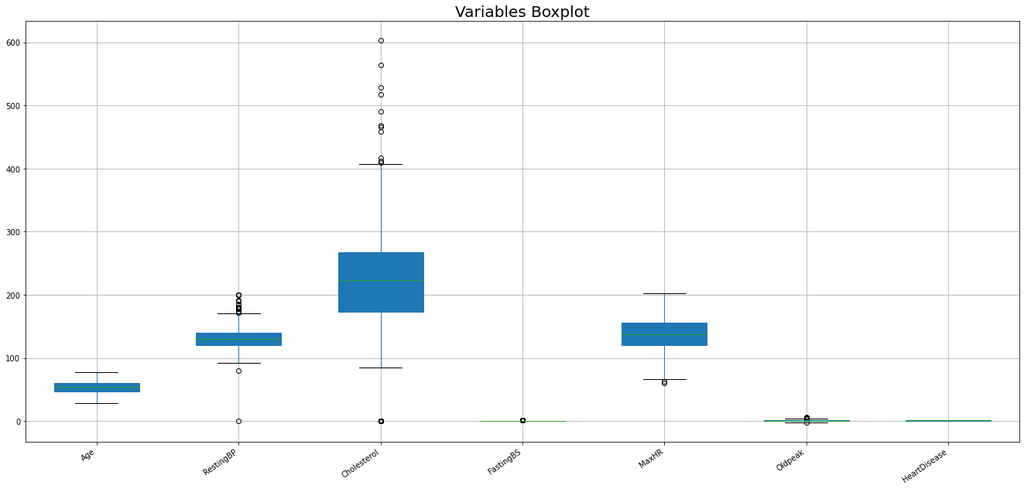

```python
fig, ax, = plt.subplots(1, figsize = (23, 10))
patient.boxplot(widths = 0.6, patch_artist = True)
plt.xticks(rotation = 35, ha='right')
plt.xlabel('')
plt.title("Variables Boxplot", fontsize=20)
plt.show()
```

##### Observation

- We have some condidate outliers in Cholesterol that should be checked. Also we need to look at Oldpeak in a seprate plot

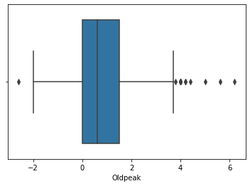

```python
sns.boxplot(x='Oldpeak', data=patient)
```

##### Observation

- Oldpeak also have some possible outliers variable that can be dropped. It should be noted that domain knowledge is necesary to decide whatever a value should be dropped or not. In our case we just visually decided to drop Oldpeak value less than -2 and more than 5 and for Cholestrol less than 50 and more than 450 just for imputation practice.

#### Imputation for two variable; Cholesterol and Oldpeak

- The mean is a good choice for imputing missing values when the data is normally distributed or when there are no significant outliers in the dataset. On the other hand, if the data is skewed or has significant outliers, the median may be a better choice for imputation. The median is less sensitive to outliers and extreme values, and may provide a more accurate estimate of the typical value in such cases. So, we check the distribution of these two variable to decide about the method

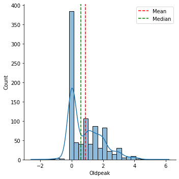

```python
sns.displot(data=patient, x='Oldpeak', kde=True)
mean_val = patient['Oldpeak'].mean()
median_val = patient['Oldpeak'].median()
plt.axvline(mean_val, color='red', linestyle='--', label='Mean')
plt.axvline(median_val, color='green', linestyle='--', label='Median')
plt.legend()
plt.show()
```

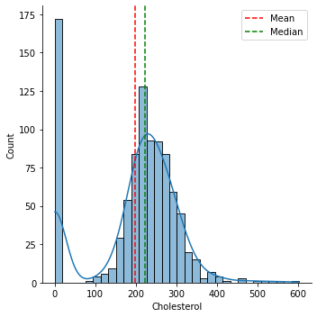

```python
sns.displot(data=patient, x='Cholesterol', kde=True)
mean_val = patient['Cholesterol'].mean()
median_val = patient['Cholesterol'].median()
plt.axvline(mean_val, color='red', linestyle='--', label='Mean')
plt.axvline(median_val, color='green', linestyle='--', label='Median')
plt.legend()
plt.show()
```

##### Observation

- As both variable seems to be skewed, the median should a better choice for imputation

```python
Oldpeak_median = patient['Oldpeak'].median()

# impute values greater than 450 or below 50 with the median of the feature
patient.loc[patient['Oldpeak'] >= 5, 'Oldpeak'] = Oldpeak_median
patient.loc[patient['Oldpeak'] < -2, 'Oldpeak'] = Oldpeak_median
```

```python
Cholesterol_median = patient['Cholesterol'].median()

# impute values greater than 450 or below 50 with the median of the feature
patient.loc[patient['Cholesterol'] > 450, 'Cholesterol'] = Cholesterol_median
patient.loc[patient['Cholesterol'] < 50, 'Cholesterol'] = Cholesterol_median
```

#### Distribution after dropping outliers

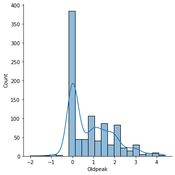

```python
sns.displot(data=patient, x='Oldpeak', kde=True)
```

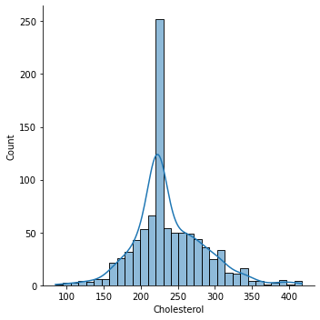

```python
sns.displot(data=patient, x='Cholesterol', kde=True)
```

#### Convert categorical data into numerical

##### One_hot Encoding

- One-hot encoding is a technique for converting categorical data into numerical data by creating a new binary column for each unique category in the categorical feature, where a value of 1 indicates the presence of the category in the original feature.

```python
patient = pd.get_dummies(patient)
patient.head()
```

|  | Age | RestingBP | Cholesterol | FastingBS | MaxHR | Oldpeak | HeartDisease | Sex_F | Sex_M | ChestPainType_ASY | ... | ChestPainType_NAP | ChestPainType_TA | RestingECG_LVH | RestingECG_Normal | RestingECG_ST | ExerciseAngina_N | ExerciseAngina_Y | ST_Slope_Down | ST_Slope_Flat | ST_Slope_Up |
| --- | --- | --- | --- | --- | --- | --- | --- | --- | --- | --- | --- | --- | --- | --- | --- | --- | --- | --- | --- | --- | --- |
| 0 | 40 | 140 | 289 | 0 | 172 | 0.0 | 0 | 0 | 1 | 0 | ... | 0 | 0 | 0 | 1 | 0 | 1 | 0 | 0 | 0 | 1 |
| 1 | 49 | 160 | 180 | 0 | 156 | 1.0 | 1 | 1 | 0 | 0 | ... | 1 | 0 | 0 | 1 | 0 | 1 | 0 | 0 | 1 | 0 |
| 2 | 37 | 130 | 283 | 0 | 98 | 0.0 | 0 | 0 | 1 | 0 | ... | 0 | 0 | 0 | 0 | 1 | 1 | 0 | 0 | 0 | 1 |
| 3 | 48 | 138 | 214 | 0 | 108 | 1.5 | 1 | 1 | 0 | 1 | ... | 0 | 0 | 0 | 1 | 0 | 0 | 1 | 0 | 1 | 0 |
| 4 | 54 | 150 | 195 | 0 | 122 | 0.0 | 0 | 0 | 1 | 0 | ... | 1 | 0 | 0 | 1 | 0 | 1 | 0 | 0 | 0 | 1 |

5 rows × 21 columns

##### OrdinalEncoder

- OrdinalEncoder is a transformer in scikit-learn that encodes categorical features as ordinal integers based on the order of the categories, where the smallest integer corresponds to the first category and the largest integer corresponds to the last category. below you can see the code but we did not use this method

# from sklearn.preprocessing import OrdinalEncoder

# features[['Sex','ChestPainType','RestingECG','ExerciseAngina','ST_Slope']]=oe.fit_transform(features[['Sex','ChestPainType','RestingECG','ExerciseAngina','ST_Slope']])

#### Rescale features to a narrow range

```python
from sklearn.preprocessing import MinMaxScaler
scaler=MinMaxScaler()
patient.iloc[:,:] = scaler.fit_transform(patient.iloc[:,:])
```

```python
patient.head()
```

|  | Age | RestingBP | Cholesterol | FastingBS | MaxHR | Oldpeak | HeartDisease | Sex_F | Sex_M | ChestPainType_ASY | ... | ChestPainType_NAP | ChestPainType_TA | RestingECG_LVH | RestingECG_Normal | RestingECG_ST | ExerciseAngina_N | ExerciseAngina_Y | ST_Slope_Down | ST_Slope_Flat | ST_Slope_Up |
| --- | --- | --- | --- | --- | --- | --- | --- | --- | --- | --- | --- | --- | --- | --- | --- | --- | --- | --- | --- | --- | --- |
| 0 | 0.244898 | 0.70 | 0.614458 | 0.0 | 0.788732 | 0.312500 | 0.0 | 0.0 | 1.0 | 0.0 | ... | 0.0 | 0.0 | 0.0 | 1.0 | 0.0 | 1.0 | 0.0 | 0.0 | 0.0 | 1.0 |
| 1 | 0.428571 | 0.80 | 0.286145 | 0.0 | 0.676056 | 0.468750 | 1.0 | 1.0 | 0.0 | 0.0 | ... | 1.0 | 0.0 | 0.0 | 1.0 | 0.0 | 1.0 | 0.0 | 0.0 | 1.0 | 0.0 |
| 2 | 0.183673 | 0.65 | 0.596386 | 0.0 | 0.267606 | 0.312500 | 0.0 | 0.0 | 1.0 | 0.0 | ... | 0.0 | 0.0 | 0.0 | 0.0 | 1.0 | 1.0 | 0.0 | 0.0 | 0.0 | 1.0 |
| 3 | 0.408163 | 0.69 | 0.388554 | 0.0 | 0.338028 | 0.546875 | 1.0 | 1.0 | 0.0 | 1.0 | ... | 0.0 | 0.0 | 0.0 | 1.0 | 0.0 | 0.0 | 1.0 | 0.0 | 1.0 | 0.0 |
| 4 | 0.530612 | 0.75 | 0.331325 | 0.0 | 0.436620 | 0.312500 | 0.0 | 0.0 | 1.0 | 0.0 | ... | 1.0 | 0.0 | 0.0 | 1.0 | 0.0 | 1.0 | 0.0 | 0.0 | 0.0 | 1.0 |

5 rows × 21 columns

##### Observation

- All variables are rescaled between 0 and 1

## Modeling

#### Splitting train and test data

- we split the dataset into 70% for training and 30% for testing the model. HeatDisease as or target value are considered as y and other variables as x

```python
x = patient.drop('HeartDisease',axis=1)
y = patient['HeartDisease']
from sklearn.model_selection import train_test_split
x_train,x_test,y_train,y_test=train_test_split(x,y,random_state=1,test_size=0.3)
```

```python
x_train.shape
```

```
(642, 20)
```

```python
x_test.shape
```

```
(276, 20)
```

#### K-Nearest Neighbour (KNN)

- K-Nearest Neighbors (KNN) is a machine learning algorithm used for both classification and regression tasks. It works by finding the K closest data points in the training set to a new input point and assigning the label of the majority class among these K neighbors to the new point. It is simple and intuitive, but can be computationally expensive for large datasets and may not perform well with high-dimensional data.
- Always normalize data befor KNN because features with larger scales may dominate the distance calculations and bias the algorithm towards those features

```python
from sklearn.neighbors import KNeighborsClassifier
knn = KNeighborsClassifier(n_neighbors=5)
knn.fit(x_train,y_train)
```

```
KNeighborsClassifier()
```

##### Reporting and Evaluating the KNN model

```python
from sklearn.metrics import accuracy_score, confusion_matrix,classification_report

TrainAC = accuracy_score(y_train, knn.predict(x_train))
TrainCM = confusion_matrix(y_train,knn.predict(x_train))
TrainCR = classification_report(y_train,knn.predict(x_train))

print(f"Train Accuracy score:{TrainAC}\nTrain Confusion Matrix:\n{TrainCM}\n Train Classification report:\n{TrainCR}")

TestAC = accuracy_score(y_test, knn.predict(x_test))
TestCM = confusion_matrix(y_test,knn.predict(x_test))
TestCR = classification_report(y_test,knn.predict(x_test))

print(f"Test Accuracy score:{TestAC}\n Test Confusion Matrix:\n{TestCM}\n Test Classification report:\n{TestCR}")
```

```
Train Accuracy score:0.8722741433021807
Train Confusion Matrix:
[[248  53]
 [ 29 312]]
 Train Classification report:
              precision    recall  f1-score   support

         0.0       0.90      0.82      0.86       301
         1.0       0.85      0.91      0.88       341

    accuracy                           0.87       642
   macro avg       0.88      0.87      0.87       642
weighted avg       0.87      0.87      0.87       642

Test Accuracy score:0.855072463768116
 Test Confusion Matrix:
[[ 89  20]
 [ 20 147]]
 Test Classification report:
              precision    recall  f1-score   support

         0.0       0.82      0.82      0.82       109
         1.0       0.88      0.88      0.88       167

    accuracy                           0.86       276
   macro avg       0.85      0.85      0.85       276
weighted avg       0.86      0.86      0.86       276
```

##### Observation

- As our model has more accuracy on the training set, it can be considered as a Overfitting Issue. To tackle this peroblem we can use Hyperparameter tuning.

##### Hyperparameter tuning

```python
Trainaccuracy=[]
Testaccuracy=[]

for i in range(1,50):
    knn=KNeighborsClassifier(n_neighbors=i)
    knn.fit(x_train,y_train)

    tra=knn.score(x_train,y_train)
    tsa=knn.score(x_test,y_test)

    Trainaccuracy.append(tra)
    Testaccuracy.append(tsa)
```

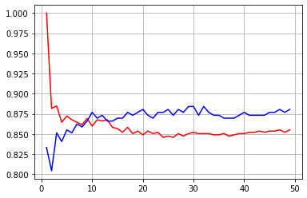

```python
plt.plot(range(1,50),Trainaccuracy,color="red")
plt.plot(range(1,50),Testaccuracy,color="blue")
plt.grid()
plt.show()
```

```python
knn=KNeighborsClassifier(n_neighbors=7)
knn.fit(x_train,y_train)

tr=knn.score(x_train,y_train)
te=knn.score(x_test,y_test)

Trainaccuracy.append(tr)
Testaccuracy.append(te)
print(f"Training acc: {tr}\nTesting acc:{te}")
```

```
Training acc: 0.8644859813084113
Testing acc:0.8623188405797102
```

##### Observation

- this method could enhance the performance of our model in test set and tackle the problem of overfitting

#### SVM Modeling

```python
from sklearn.svm import SVC
svm=SVC()
svm.fit(x_train,y_train)
y_predict =svm.predict(x_test)
```

```python
TrainAC = accuracy_score(y_train, svm.predict(x_train))
TrainCM = confusion_matrix(y_train,svm.predict(x_train))
TrainCR = classification_report(y_train,svm.predict(x_train))

print(f"Train Accuracy score:{TrainAC}\nTrain Confusion Matrix:\n{TrainCM}\n Train Classification report:\n{TrainCR}")

TestAC = accuracy_score(y_test, svm.predict(x_test))
TestCM = confusion_matrix(y_test,svm.predict(x_test))
TestCR = classification_report(y_test,svm.predict(x_test))

print(f"Test Accuracy score:{TestAC}\n Test Confusion Matrix:\n{TestCM}\n Test Classification report:\n{TestCR}")
```

```
Train Accuracy score:0.8722741433021807
Train Confusion Matrix:
[[249  52]
 [ 30 311]]
 Train Classification report:
              precision    recall  f1-score   support

         0.0       0.89      0.83      0.86       301
         1.0       0.86      0.91      0.88       341

    accuracy                           0.87       642
   macro avg       0.87      0.87      0.87       642
weighted avg       0.87      0.87      0.87       642

Test Accuracy score:0.8804347826086957
 Test Confusion Matrix:
[[ 91  18]
 [ 15 152]]
 Test Classification report:
              precision    recall  f1-score   support

         0.0       0.86      0.83      0.85       109
         1.0       0.89      0.91      0.90       167

    accuracy                           0.88       276
   macro avg       0.88      0.87      0.87       276
weighted avg       0.88      0.88      0.88       276
```

#### Decision tree classification

- It works by recursively partitioning the data into subsets based on the values of input features, and creating a tree-like model that can be used to make predictions on new data

```python
from sklearn.tree import DecisionTreeClassifier
Tree = DecisionTreeClassifier(max_depth=5)
Tree.fit(x_train,y_train)

TrainAC = accuracy_score(y_train, Tree.predict(x_train))
TrainCM = confusion_matrix(y_train,Tree.predict(x_train))
TrainCR = classification_report(y_train,Tree.predict(x_train))

print(f"Train Accuracy score:{TrainAC}\nTrain Confusion Matrix:\n{TrainCM}\n Train Classification report:\n{TrainCR}")

TestAC = accuracy_score(y_test, Tree.predict(x_test))
TestCM = confusion_matrix(y_test,Tree.predict(x_test))
TestCR = classification_report(y_test,Tree.predict(x_test))

print(f"Test Accuracy score:{TestAC}\n Test Confusion Matrix:\n{TestCM}\n Test Classification report:\n{TestCR}")
```

```
Train Accuracy score:0.8613707165109035
Train Confusion Matrix:
[[240  61]
 [ 28 313]]
 Train Classification report:
              precision    recall  f1-score   support

         0.0       0.90      0.80      0.84       301
         1.0       0.84      0.92      0.88       341

    accuracy                           0.86       642
   macro avg       0.87      0.86      0.86       642
weighted avg       0.86      0.86      0.86       642

Test Accuracy score:0.8514492753623188
 Test Confusion Matrix:
[[ 87  22]
 [ 19 148]]
 Test Classification report:
              precision    recall  f1-score   support

         0.0       0.82      0.80      0.81       109
         1.0       0.87      0.89      0.88       167

    accuracy                           0.85       276
   macro avg       0.85      0.84      0.84       276
weighted avg       0.85      0.85      0.85       276
```

#### Grid Search to find best parameters

```python
parameter={
    "criterion":["gini","entropy"],
    "max_depth":[1, 3, 5, 7, 9],
    "min_samples_leaf":list(range(2,20))
}
from sklearn.model_selection import GridSearchCV
grid=GridSearchCV(DecisionTreeClassifier(),parameter,verbose=10)
grid.fit(x_train,y_train)
```

[output not shown]

[output cut: 1746 more lines]

[output not shown]

```
GridSearchCV(estimator=DecisionTreeClassifier(),
             param_grid={'criterion': ['gini', 'entropy'],
                         'max_depth': [1, 3, 5, 7, 9],
                         'min_samples_leaf': [2, 3, 4, 5, 6, 7, 8, 9, 10, 11,
                                              12, 13, 14, 15, 16, 17, 18, 19]},
             verbose=10)
```

```python
grid.best_score_
```

```
0.8364341085271316
```

```python
grid.best_estimator_
```

```
DecisionTreeClassifier(max_depth=3, min_samples_leaf=2)
```

##### Testing DT model with best estimator from Grid Search

```python
from sklearn.tree import DecisionTreeClassifier
Tree = DecisionTreeClassifier(max_depth=3, min_samples_leaf=2)
Tree.fit(x_train,y_train)

TrainAC = accuracy_score(y_train, Tree.predict(x_train))
TestAC = accuracy_score(y_test, Tree.predict(x_test))

print(f"Train Accuracy score:{TrainAC}\nTest Accuracy score:{TestAC}")
```

```
Train Accuracy score:0.8613707165109035
Test Accuracy score:0.8514492753623188
```

## Conclusion

##### ROC plot

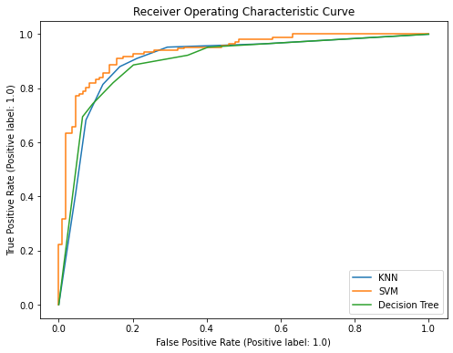

```python
from sklearn.metrics import plot_confusion_matrix,roc_auc_score, roc_curve, f1_score, accuracy_score
from sklearn.metrics import make_scorer, precision_score, precision_recall_curve, plot_precision_recall_curve
from sklearn.metrics import recall_score, plot_roc_curve
fig, ax = plt.subplots(figsize=(8, 6))
plot_roc_curve(knn, x_test, y_test, ax=ax, label='KNN')
plot_roc_curve(svm, x_test, y_test, ax=ax, label='SVM')
plot_roc_curve(Tree, x_test, y_test, ax=ax, label='Decision Tree')
plt.title('Receiver Operating Characteristic Curve')
plt.legend()
plt.show()
```

```python
y_pred_proba_dt = knn.predict_proba(x_test)[:,1]
auc_dt = roc_auc_score(y_test, y_pred_proba_dt)
print("AUC for Decision Tree: {:.3f}".format(auc_dt))

y_pred_proba_svm = svm.decision_function(x_test)
auc_svm = roc_auc_score(y_test, y_pred_proba_svm)
print("AUC for SVM: {:.3f}".format(auc_svm))

y_pred_proba_knn = Tree.predict_proba(x_test)[:,1]
auc_knn = roc_auc_score(y_test, y_pred_proba_knn)
print("AUC for KNN: {:.3f}".format(auc_knn))
```

[output not shown]